# Summarize MVP MtDNA Analysis results

28 November, 2023

```r
rm(list=ls())
library(PheWAS)
# install.packages(c("dplyr","tidyr","ggplot2","MASS","meta","ggrepel","DT"))
# devtools::install_github("PheWAS/PheWAS")

library(plotly)
library(forestplot)
library(geomtextpath)
library(colorspace)
library(scales)
library(grid)
library(khroma)
library("formatdown")
#library(readxl)
#library(filesstrings)
#library(UpSetR)

library(purrr)
library(data.table)
library(ComplexUpset)
library(knitr)
library(tidyr)
library(magrittr)
library(readr)
# library(xlsx)
library(readxl)
library(dplyr)
library(ggplot2)
library(ggrepel)
library(stringi)
library(stringr)
```

## Load Info

- Summary of PheCodes in each population

```r
phecode_summ <- fread("../summary/MVP_summaries/summary_phecodes_by_GIA.sex.pop.vPAD.txt",
                      colClasses = c(phecode = "character")) %>%
  dplyr::rename(RACE = GIA, SEX = sex, POP = pop) %>%
  dplyr::select(-COHORT)
```

- Supplementary Table 1: cardio-metabolic PheCodes

```r
#Phecodes related to cardiometabolic with >= 500 cases in any population
phecodes_analyzed <- fread("../summary/MVP_summaries/cardiometabolic_liver_phecodes.txt",
                           colClasses = c(phecode = "character")) %>%
  left_join(phecode_summ) %>%
  group_by(phecode) %>%
  filter(SEX == "allsex" &
         POP == "all" &
         RACE %in% c("AFR_GIA", "AMR_GIA", "EUR_GIA", "EAS_GIA")) %>%
  mutate(RACE = gsub("_GIA", "", RACE)) %>%
  filter(any(n_cases >= 500)) %>%
  mutate(`N (%)` = paste0(n_cases, " (", round(prop_cases*100, 2), ")")) %>%
  mutate(`N (%)` = ifelse(n_cases < 500, "< 500", `N (%)`)) %>%
  dplyr::select(-n_cases, -prop_cases) %>%
  pivot_wider(names_from = "RACE", values_from = `N (%)`, names_prefix = "N (%) ") %>%
  #322 actual from 365 relevant
  dplyr::select(phecode, description, group, `N (%) EUR`, `N (%) AFR`, `N (%) AMR`, `N (%) EAS`)
table(phecodes_analyzed$group)
```

```
##
##   circulatory system congenital anomalies            digestive
##                  161                    6                   18
##  endocrine/metabolic
##                  137
```

```r
phecodes_analyzed %>% filter(group %in% c("congenital anomalies", "digestive"))
```

```
## # A tibble: 24 × 7
## # Groups:   phecode [24]
##    phecode description     group `N (%) EUR` `N (%) AFR` `N (%) AMR` `N (%) EAS`
##    <chr>   <chr>           <chr> <chr>       <chr>       <chr>       <chr>
##  1 571     Chronic liver … dige… 48592 (11.… 13644 (11.… 8717 (15.9… 1204 (11.4…
##  2 571.5   Other chronic … dige… 46533 (10.… 13040 (11.… 8478 (15.5… 1178 (11.2)
##  3 571.51  Cirrhosis of l… dige… 17077 (3.9) 6336 (5.53) 3086 (5.65) < 500
##  4 571.8   Liver abscess … dige… 8420 (1.92) 2076 (1.81) 1348 (2.47) < 500
##  5 571.81  Portal hyperte… dige… 5403 (1.23) 1087 (0.95) 897 (1.64)  < 500
##  6 572     Ascites (non m… dige… 8080 (1.85) 2190 (1.91) 1102 (2.02) < 500
##  7 573     Other disorder… dige… 18810 (4.3) 6008 (5.24) 2495 (4.57) < 500
##  8 573.1   Chronic passiv… dige… 663 (0.15)  < 500       < 500       < 500
##  9 573.2   Liver replaced… dige… 1199 (0.27) < 500       < 500       < 500
## 10 573.3   Hepatomegaly    dige… 9685 (2.21) 2710 (2.37) 1466 (2.68) < 500
## # ℹ 14 more rows
```

```r
# write_xlsx(phecodes_analyzed %>% data.frame(.),
# "../summary/MVP_summaries/phecodes_analyzed.xlsx", row.names=F)
```

- Multiallelic SNPs to exclude

```r
multiallelic_snps <- c("AX-37116935", "AX-83589457",
                       "AX-98077966", "AX-98077957",
                       "AX-83452320", "AX-98077978",
                       "AX-98078001")
```

- Load annotation file provided by Genisis support and annotations extracted from Hmtvar database

```r
anno_mvp <-  read_xlsx("../../../MVP mitochondria SNPs annotation 20200710.xlsx")  %>%
  select(`dbSNP RS ID`, `NC_012920 (rCRS) Physical Position`) %>%
  rename(BP = `NC_012920 (rCRS) Physical Position`)

anno <- read_xlsx("../hmtvar/Suppl.xlsx", skip = 1) %>%
  dplyr::select(ID, BP, dbSNP, Locus, Pathogenicity,
                MITOMAP_disease = `MITOMAP disease`) %>%
  left_join(read_xlsx("../summary/aa_changes.xlsx"))
anno <-  anno %>%
         left_join(anno_mvp, by = c("BP")) %>%
         select(-dbSNP) %>%
         rename(dbSNP = `dbSNP RS ID`)
```

- Load MT base info for solar plots

```r
(refflat <- read_table(
  paste(analysis_dir, "summary/gene_definitions/gencode_mt_refFlat.txt", sep = ""),
  col_names = F) %>%
  select(1, 5, 6, 9) %>%
  set_names(c("gene", "start", "end", "ctrl")) %>%
  mutate(gene = gsub("MT-", "", gene)))
```

```
## # A tibble: 37 × 4
##    gene  start   end  ctrl
##    <chr> <dbl> <dbl> <dbl>
##  1 TF      576   647     1
##  2 RNR1    647  1601     1
##  3 TV     1601  1670     1
##  4 RNR2   1670  3229     1
##  5 TL1    3229  3304     1
##  6 ND1    3306  4262     1
##  7 TI     4262  4331     1
##  8 TQ     4328  4400     1
##  9 TM     4401  4469     1
## 10 ND2    4469  5511     1
## # ℹ 27 more rows
```

```r
pos_gene <- tibble(
    POS = seq(0, 16567),
    ctrl = 1) %>%
    full_join(refflat) %>%
    filter(POS >= start & POS <= end) %>%
    dplyr::select(-ctrl, start, end) %>%
    group_by(POS) %>%
    dplyr::slice(1) %>%
    mutate(bp = POS) %>%
    ungroup()
(refflat_length <- refflat %>%
  dplyr::rename(Gene = gene) %>%
  mutate(gene_length = end - start,
         add_pos = cumsum(gene_length) - 71) %>%
  mutate(small_gene = ifelse(gene_length < 350, 1, 0)) %>%
  mutate(pos.rt = 360 -((start + gene_length/2)/(16023))*360))
```

```
## # A tibble: 37 × 8
##    Gene  start   end  ctrl gene_length add_pos small_gene pos.rt
##    <chr> <dbl> <dbl> <dbl>       <dbl>   <dbl>      <dbl>  <dbl>
##  1 TF      576   647     1          71       0          1   346.
##  2 RNR1    647  1601     1         954     954          0   335.
##  3 TV     1601  1670     1          69    1023          1   323.
##  4 RNR2   1670  3229     1        1559    2582          0   305.
##  5 TL1    3229  3304     1          75    2657          1   287.
##  6 ND1    3306  4262     1         956    3613          0   275.
##  7 TI     4262  4331     1          69    3682          1   263.
##  8 TQ     4328  4400     1          72    3754          1   262.
##  9 TM     4401  4469     1          68    3822          1   260.
## 10 ND2    4469  5511     1        1042    4864          0   248.
## # ℹ 27 more rows
```

```r
(refflat_length_small_plothelp <- refflat_length %>%
  filter(small_gene == 1) %>%
  mutate(plot_pos = case_when(
    Gene %in% c("TF", "TM", "TC", "TD", "ATP8", "TL2") ~ start + gene_length/2 + 60,
    Gene %in% c("TI", "TA", "TH", "TT")  ~ start + gene_length/2 - 60,
    Gene %in% c("TY")  ~ start + gene_length/2 + 120,
    Gene %in% c("TW")  ~ start + gene_length/2 - 120,
    TRUE ~ start + gene_length/2)
  ))
```

```
## # A tibble: 25 × 9
##    Gene  start   end  ctrl gene_length add_pos small_gene pos.rt plot_pos
##    <chr> <dbl> <dbl> <dbl>       <dbl>   <dbl>      <dbl>  <dbl>    <dbl>
##  1 TF      576   647     1          71       0          1   346.     672.
##  2 TV     1601  1670     1          69    1023          1   323.    1636.
##  3 TL1    3229  3304     1          75    2657          1   287.    3266.
##  4 TI     4262  4331     1          69    3682          1   263.    4236.
##  5 TQ     4328  4400     1          72    3754          1   262.    4364
##  6 TM     4401  4469     1          68    3822          1   260.    4495
##  7 TW     5511  5579     1          68    4932          1   235.    5425
##  8 TA     5586  5655     1          69    5001          1   234.    5560.
##  9 TN     5656  5729     1          73    5074          1   232.    5692.
## 10 TC     5760  5826     1          66    5140          1   230.    5853
## # ℹ 15 more rows
```

```r
(bprange <- refflat %>%
  filter(!grepl("^T", gene)) %>%
  dplyr::select(-ctrl) %>%
  mutate(BP = paste0( start, "-", end)) %>%
  mutate(SetID = paste0("MT-", gene)) %>%
  dplyr::select(-gene, -start, -end))
```

```
## # A tibble: 15 × 2
##    BP          SetID
##    <chr>       <chr>
##  1 647-1601    MT-RNR1
##  2 1670-3229   MT-RNR2
##  3 3306-4262   MT-ND1
##  4 4469-5511   MT-ND2
##  5 5903-7445   MT-CO1
##  6 7585-8269   MT-CO2
##  7 8365-8572   MT-ATP8
##  8 8526-9207   MT-ATP6
##  9 9206-9990   MT-CO3
## 10 10058-10404 MT-ND3
## 11 10469-10766 MT-ND4L
## 12 10759-12137 MT-ND4
## 13 12336-14148 MT-ND5
## 14 14148-14673 MT-ND6
## 15 14746-15887 MT-CYB
```

## Define data encoding keys and color schema for plots

- Define data encoding keys

```r
biomarker_key <- c("a1c" = "HbA1c",
                   "tg" = "Triglycerides",
                   "bmi" = "BMI",
                   "ldlc" = "LDL",
                   "hdlc" = "HDL",

                   "tg_adj" = "Triglycerides",
                   "ldlc_adj" = "LDL",
                   "hdlc_adj" = "HDL",

                   "tg_adj_INT" = "Triglycerides",
                   "ldlc_adj_INT" = "LDL",
                   "hdlc_adj_INT" = "HDL")

race_key <- c("AFR_GIA" = "African",
             "EUR_GIA" = "European",
             "EAS_GIA" = "East Asian",
             "AMR_GIA" = "Admixed American",
             "TE_META" = "Trans-Ethnic Meta-analysis")

sex_key <- c("males" = "Males",
            "females" = "Females",
            "allsex" = "Males + Females")

sex_key2 <- c("males" = "Males",
            "females" = "Females",
            "allsex" = "")

pop_key <- c("t2d" = "T2D",
             "nondiab" = "Non DM",
             "all" = "All")

sex_pop_key <- c("t2dmales" = "Males with T2D",
                 "t2dfemales" = "Females with T2D",
                 "t2dallsex" = "All T2D",
                 "nondiabmales" = "Non-diabetic Males",
                 "nondiabfemales" = "Non-diabetic Females",
                 "nondiaballsex" = "All Non-diabetics",
                 "allmales" = "All Males",
                 "allfemales" = "All Females",
                 "allallsex"= "All")

sex_pop_key2 <- c("t2dmales" = "Males with T2D",
                 "t2dfemales" = "Females with T2D",
                 "t2dallsex" = "T2D",
                 "nondiabmales" = "Non-diabetic Males",
                 "nondiabfemales" = "Non-diabetic Females",
                 "nondiaballsex" = "Non-diabetics",
                 "allmales" = "Males",
                 "allfemales" = "Females",
                 "allallsex"= "All")
```

- Functions and colors to use in plots

```r
### some code is from stephen turner solarplot.R, modified ####
addgenelabel <- function(bp) {
  gene <- left_join(data.frame(bp), pos_gene)
  gene$gene[is.na(gene$gene) & gene$bp < 577] <- "Control-Region"
  gene <- gene %>% dplyr::select(gene)
  return(gene$gene)
}

lighten_col <- function(col){
  col1 = RGB(col2rgb(col)[1]/255, col2rgb(col)[2]/255, col2rgb(col)[3]/255)
  col2 = RGB(1,1,1)
  newcol <- colorspace::mixcolor(0.4, col1, col2)
  newcol_char <- rgb(newcol@coords[,1], newcol@coords[,2], newcol@coords[,3])
  return(newcol_char)
}

 # Set colors for each gene
colours_solid <- c("Control-Region" = "lightblue4",
                   "tRNA" = "magenta4",
                   "TF" = "magenta4",
                   "RNR1" = "mediumaquamarine",
                   "TV" = "magenta4",
                   # "Non-Coding" = "sienna4",
                   "RNR2" = "aquamarine",
                   "TL1" = "magenta4",
                   "ND1" = "magenta",
                   "TI" = "magenta4",
                   "TQ" = "magenta4",
                   "TM" = "magenta4",
                   "ND2" = "mediumblue",
                   "TW" = "magenta4",
                   "TA" = "magenta4",
                   "TN" = "magenta4",
                   "TC" = "magenta4",
                   "TY" = "magenta4",
                   "CO1" = "olivedrab",
                   "TS1" = "magenta4",
                   "TD" = "magenta4",
                   "TK" = "magenta4",
                   "CO2" = "orange2",
                   "ATP8" = "orchid4",
                   "ATP6" = "red3",
                   "CO3" = "royalblue2",
                   "TG" = "magenta4",
                   "ND3" = "palegreen4",
                   "TR" = "magenta4",
                   "ND4L" = "grey0",
                   "ND4" = "pink4",
                   "TH" = "magenta4",
                   "TS2" = "magenta4",
                   "TL2" = "magenta4",
                   "ND5" = "yellow4",
                   "ND6" = "steelblue4",
                   "TE" = "magenta4",
                   "CYB" = "tan",
                   "TT" = "magenta4",
                   "TP" = "magenta4")
#colours <- t_col(colours_solid, name = names(colours_solid))
colours <- lapply(colours_solid, lighten_col) %>% unlist()
colours
```

```
## Control-Region           tRNA             TF           RNR1             TV
##      "#A4B5B9"      "#B966B9"      "#B966B9"      "#A3E1CC"      "#B966B9"
##           RNR2            TL1            ND1             TI             TQ
##      "#B2FFE5"      "#B966B9"      "#FF66FF"      "#B966B9"      "#B966B9"
##             TM            ND2             TW             TA             TN
##      "#B966B9"      "#6666E1"      "#B966B9"      "#B966B9"      "#B966B9"
##             TC             TY            CO1            TS1             TD
##      "#B966B9"      "#B966B9"      "#A6BB7B"      "#B966B9"      "#B966B9"
##             TK            CO2           ATP8           ATP6            CO3
##      "#B966B9"      "#F5C266"      "#B991B8"      "#E16666"      "#8EA8F5"
##             TG            ND3             TR           ND4L            ND4
##      "#B966B9"      "#98B998"      "#B966B9"      "#666666"      "#B9A1A7"
##             TH            TS2            TL2            ND5            ND6
##      "#B966B9"      "#B966B9"      "#B966B9"      "#B9B966"      "#86A2B9"
##             TE            CYB             TT             TP
##      "#B966B9"      "#E4D2BA"      "#B966B9"      "#B966B9"
```

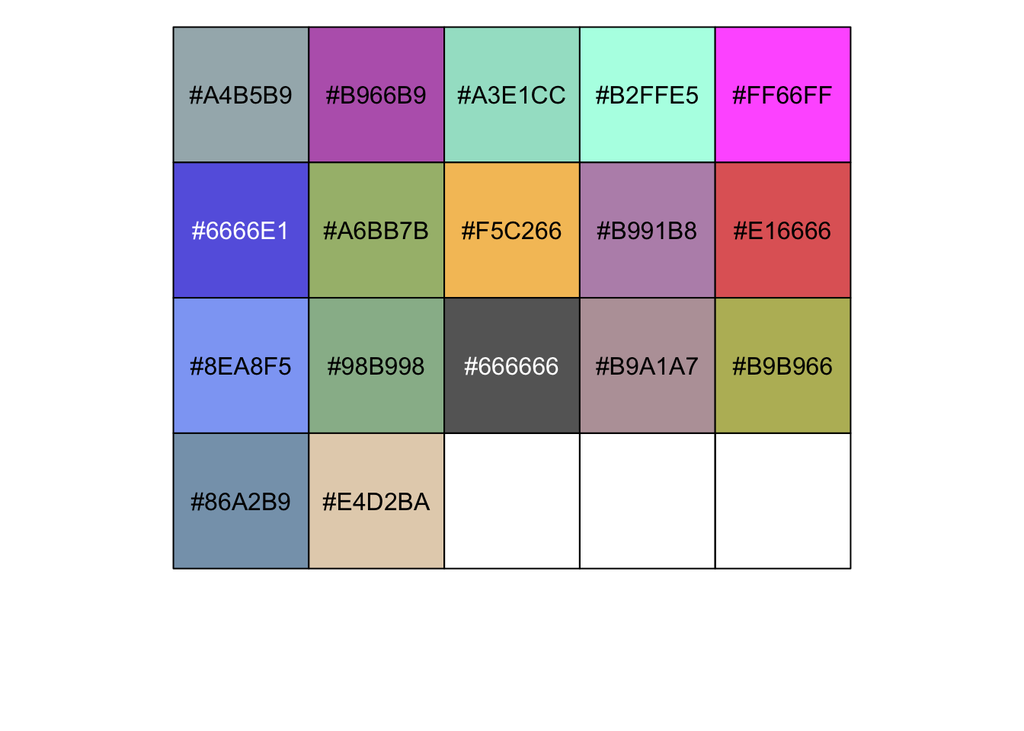

```r
show_col(unique(colours))
```

## Summarize mtSNVs association analysis results

### SNP-based results (PheWAS and biomarkers)

- Read in all analysis results, including ones with errors (i.e., analysis didn’t finish successfully)
- Remove multi-alleletic SNPs
- Keep analysis results in GIA ancestry groups
- Keep analysis results adjusted for 15PCs
- Keep analysis results among most recent cohort “vPDA”

```r
d_snp_all <- fread(
  paste(analysis_dir,
        "SNPbased/ancestries/MTSNVs/results.SNPbased.firth.GIA.15PC.vPAD.txt", sep = "")) %>%
  # remove old unadjusted biomarkers
  filter(!(trait %in% c("sbp", "dbp", "hdlc", "ldlc", "tg"))) %>%
  full_join(fread("../sNPbased/ancestries/MTSNVs/results.SNPbased.biomarker_adjustments.txt") %>%
            # add adjusted biomarkers
            filter(grepl("bp_adj$|adj_INT", trait)) %>%
            dplyr::select(-`#CHROM`, -TEST,
                          -T_STAT, -filename,
                          -ASSOC_TYPE, -TEST_TYPE,
                          -ANCESTRY, -DESCRIPTOR)) %>%
  filter(COHORT == "vPAD" & NPC == "15PC"  & grepl("GIA", RACE)) %>%
  # remove multi-alleletic snps
  filter(!(ID %in% multiallelic_snps)) %>%
  dplyr::select(-COHORT, -NPC) %>%
  mutate(phecode = gsub("_", ".", gsub("phe_", "", trait)))
```

```
## COHORT, RACE, SEX, POP, TRAIT_TYPE, NPC, trait, ALT_FREQS)`
```

- Join PheCodes info and add SNP annotation

```r
d_snp_all <- d_snp_all %>%
  left_join(phecode_summ, by = c("RACE", "SEX", "POP", "phecode")) %>%
  left_join(anno %>% dplyr::rename(POS = BP))
```

## SNP-level ancestry-specific results

### Further filtering results

- More analyses were done than needed, so
  - Keep only first level subgroups
  - A1c analysis only makes sense in DM stratified groups
- Filter analysis didn’t converge and with no P
- Keep analysis results for phecodes with > 500 cases
- SNP-level analysis is for MAF > 0.001
- Note that FDR p-value needs to be calculated after filtering
  - Multiple testing correction applied separately for each ancestry/sex/population analysis
- Calculate FDR adjusted p-value
  - overall 4 ancestries,
  - 4 ancestries + SEX subgroups,
  - 4 ancestries + diabetes subgroups

```r
d_snp <- d_snp_all %>%
  # filter analysis with no error code
  filter(ERRCODE == ".") %>%
  dplyr::select(-ERRCODE) %>%
  # filter analysis didn't converge with no P
  filter(!is.na(P)) %>%
  distinct() %>%
  # only include 1-level subgroups (e.g., males, t2d, not males w/ t2d)
  filter(SEX == "allsex" | POP == "all") %>%
  # a1c needs to be stratified by dm only
  filter(!(POP == "all" & trait %in% c("a1c", "g65_hb", "g75_hb")))  %>%
  # keep analysis results for phecodes with > 500 cases
  filter(n_cases >= 500 | TRAIT_TYPE == "other_traits") %>%
  # SNP-level analysis is for MAF > 0.001
  filter(ALT_FREQS >= 0.001 & ALT_FREQS <= 0.999) %>%
  ungroup() %>%
  group_by(RACE, SEX, POP) %>%
  mutate(p_adjust_fdr = p.adjust(P, "BH"))
```

### Table 2: 9 associations

- Significant SNP-level results by controlling FDR < 0.05

```r
d_sig_fdr <- d_snp %>%
  filter(p_adjust_fdr < 0.05)
```

```r
d_sig_fdr_eur <- d_sig_fdr %>%
  filter(POP == "all" & SEX == "allsex") %>%
  # keep only 244.4 (leaves) not 244
  filter(phecode != "244") %>%
  filter(RACE == "EUR_GIA")

d_sig_fdr_afr <- d_sig_fdr %>%
  filter(POP == "all" & SEX == "allsex") %>%
  # keep only 244.4 (leaves) not 244
  filter(phecode != "244") %>%
  filter(RACE == "AFR_GIA")

snp_table1_eur <- (d_snp_all %>%
                     left_join(d_snp %>% select(POS, RACE, phecode, SEX, POP, p_adjust_fdr),
                     by = c("POS", "SEX", "RACE",  "phecode",  "POP"))) %>%
  filter(POP == "all" & SEX == "allsex") %>%
  select(-POP, -SEX) %>%
  right_join(d_sig_fdr_eur %>% ungroup %>% select(POS, phecode), by = c("POS", "phecode")) %>%
  left_join(phecodes_analyzed %>% select(phecode, description), by = "phecode") %>%
  select(RACE, POS,
         dbSNP, REF,
         ALT, A1, OBS_CT,
         Locus, ALT_FREQS,
         OR, `LOG(OR)_SE`,
         P, p_adjust_fdr,
         n_cases, prop_cases,
         variant_type, aa_change,
         phecode, description,) %>%
  mutate(RACE = factor(str_replace(RACE, "_GIA", ""), levels = c("EUR", "AFR", "AMR", "EAS")),
         altallele = A1,
         refallele = ifelse(REF == A1, ALT, REF),
         `BP/REF/ALT` = str_c(POS, "/", refallele, "/", altallele, sep = ""),
         MAF = ifelse(ALT_FREQS > 0.5, 1-ALT_FREQS, ALT_FREQS),
         Annotation = ifelse(aa_change == "NA", variant_type,
                             str_c(variant_type, ", ", aa_change, sep = ""))) %>%
  arrange(POS, phecode, RACE)  %>%
  select(-aa_change, -variant_type, -POS, -REF, -ALT) %>%
  mutate(`# Cases / N (%)` = ifelse(n_cases < 500,
                              " < 500",
                              paste(formatC(n_cases, format = "d", big.mark = ","), "/",
                                    formatC(OBS_CT, format = "d", big.mark = ","),
                                    paste0("(", round(prop_cases*100, 1), "%)"), sep=" "))) %>%
  mutate( LCI = signif(exp(log(OR) - 1.96*`LOG(OR)_SE`), 2),
          UCI = signif(exp(log(OR) + 1.96*`LOG(OR)_SE`), 2),
          P = scientific(P, digits = 3),
          p_adjust_fdr = round(p_adjust_fdr, digits = 2),
          `OR (95% CI), P-value` =
            ifelse(ALT_FREQS < 0.001 | ALT_FREQS > 0.999 | n_cases < 500,
                   "-", paste0(round(OR, 2), " (", LCI, "-" , UCI, "), ", P)),
          `FDR Adjusted P-value` = ifelse(`OR (95% CI), P-value` == "-", "-", p_adjust_fdr)) %>%
  select(-LCI, -UCI, -P, -OR, -`LOG(OR)_SE`, -n_cases, -prop_cases) %>%
  # mutate(`Alt Freq` = paste0(round(ifelse(ALT_FREQS > 0.5, 1-ALT_FREQS, ALT_FREQS)*100, 2), "%")) %>%
  mutate(`Alt AF` = ifelse(ALT_FREQS < 0.001 | ALT_FREQS > 0.999,
                             "< 0.1%",
                           paste0(round(MAF*100, 2), "%"))) %>%
  select(-ALT_FREQS) %>%
  mutate(`Description, Phecode` = paste0(description, ", ", phecode)) %>%
  select(-description, -phecode) %>%
  select(dbSNP, `BP/REF/ALT`,
         Locus, Annotation,
         `Description, Phecode`,
         RACE, `# Cases / N (%)`,
         `Alt AF`, `OR (95% CI), P-value`,
         `FDR Adjusted P-value`) %>%
  ungroup() %>%
  group_by(dbSNP) %>%
  #Don't repeat
  mutate(dbSNP = ifelse(row_number() == 1, dbSNP, ""),
         # `BP/REF/ALT` = ifelse(row_number() == 1, `BP/REF/ALT`, ""),
         Locus = ifelse(row_number() == 1, Locus, ""),
         Annotation = ifelse(row_number() == 1, Annotation, ""),
         `Description, Phecode` = ifelse(row_number() == 1, `Description, Phecode`, ""))

snp_table1_afr <- (d_snp_all %>%
                     left_join(d_snp %>% select(POS, RACE, phecode, SEX, POP, p_adjust_fdr),
                     by = c("POS", "SEX", "RACE",  "phecode",  "POP")))  %>%
  filter(POP == "all" & SEX == "allsex") %>%
  select(-POP, -SEX) %>%
  right_join(d_sig_fdr_afr %>% ungroup %>% select(POS, phecode), by = c("POS", "phecode")) %>%
  left_join(phecodes_analyzed %>% select(phecode, description), by = "phecode") %>%
  select(RACE, POS,
         dbSNP, REF,
         ALT, A1, OBS_CT,
         Locus, ALT_FREQS,
         OR, `LOG(OR)_SE`,
         P, p_adjust_fdr,
         n_cases, prop_cases,
         variant_type, aa_change,
         phecode, description) %>%
  mutate(RACE = factor(str_replace(RACE, "_GIA", ""), levels = c("EUR", "AFR", "AMR", "EAS")),
         altallele = A1,
         refallele = ifelse(REF == A1, ALT, REF),
         `BP/REF/ALT` = str_c(POS, "/", refallele, "/", altallele, sep = ""),
         MAF = ifelse(ALT_FREQS > 0.5, 1-ALT_FREQS, ALT_FREQS),
         Annotation = ifelse(aa_change == "NA", variant_type,
                             str_c(variant_type, ", ", aa_change, sep = ""))) %>%
  arrange(POS, phecode, RACE)  %>%
  select(-aa_change, -variant_type, -POS, -REF, -ALT) %>%
  mutate(`# Cases / N (%)` = ifelse(n_cases < 500,
                              " < 500",
                              paste(formatC(n_cases, format = "d", big.mark = ","), "/",
                                    formatC(OBS_CT, format = "d", big.mark = ","),
                                    paste0("(", round(prop_cases*100, 1), "%)"), sep=" "))) %>%
  mutate( LCI = signif(exp(log(OR) - 1.96*`LOG(OR)_SE`), 2),
          UCI = signif(exp(log(OR) + 1.96*`LOG(OR)_SE`), 2),
          P = scientific(P, digits = 3),
          p_adjust_fdr = round(p_adjust_fdr, digits = 2),
          `OR (95% CI), P-value` = ifelse(ALT_FREQS < 0.001 | ALT_FREQS > 0.999 | n_cases < 500,
                                          "-", paste0(round(OR, 2), " (", LCI, "-" , UCI, "), ", P)),
          `FDR Adjusted P-value` = ifelse(`OR (95% CI), P-value` == "-", "-", p_adjust_fdr)) %>%
  select(-LCI, -UCI, -P, -OR, -`LOG(OR)_SE`, -n_cases, -prop_cases) %>%
  # mutate(`Alt Freq` = paste0(round(ifelse(ALT_FREQS > 0.5, 1-ALT_FREQS, ALT_FREQS)*100, 2), "%")) %>%
  mutate(`Alt AF` = ifelse(ALT_FREQS < 0.001 | ALT_FREQS > 0.999,
                             "< 0.1%", paste0(round(MAF*100, 2), "%"))) %>%
  select(-ALT_FREQS) %>%
  mutate(`Description, Phecode` = paste0(description, ", ", phecode)) %>%
  select(-description, -phecode) %>%
  select(dbSNP, `BP/REF/ALT`,
         Locus, Annotation,
         `Description, Phecode`,
         RACE, `# Cases / N (%)`,
         `Alt AF`, `OR (95% CI), P-value`,
         `FDR Adjusted P-value`) %>%
  ungroup() %>%
  group_by(dbSNP) %>%
  #Don't repeat
  mutate(dbSNP = ifelse(row_number() == 1, dbSNP, ""),
         # `BP/REF/ALT` = ifelse(row_number() == 1, `BP/REF/ALT`, ""),
         Locus = ifelse(row_number() == 1, Locus, ""),
         Annotation = ifelse(row_number() == 1, Annotation, ""),
         `Description, Phecode` = ifelse(row_number() == 1, `Description, Phecode`, ""))

snp_table1 <- bind_rows(snp_table1_eur, snp_table1_afr)
# write_csv(snp_table1, "../tables/table1.csv")
```

- Output all reported mtSNVs

```r
mtsnvs <- d_sig_fdr %>%
  filter(POP != "nondiab") %>%
  ungroup %>%
  select(POS, RACE, SEX, POP) %>%
  distinct() %>%
  arrange(POS) %>%
  mutate(POS = paste("MT", POS, sep = "")) %>%
  mutate(RACE = str_replace(RACE, "_GIA", "")) %>%
  mutate(population = case_when(SEX == "allsex" & POP == "all" ~ "All",
                                SEX == "allsex" & POP == "t2d" ~ "T2D",
                                SEX == "males" & POP == "all" ~ "Males",
                                SEX == "females" & POP == "all" ~ "Females")) %>%
  select(-SEX, -POP)

write_csv(mtsnvs, "../tables/reported_mtsnvs.csv")
```

- Output all reporeted PheCodes

```r
# output all report phecodes
unique_phecodes <- d_sig_fdr %>%
  filter(POP != "nondiab") %>%
  ungroup %>%
  select(phecode) %>%
  distinct() %>%
  left_join(phecodes_analyzed %>% select(phecode, description, group)) %>%
  arrange(phecode)

write_csv(unique_phecodes, "../tables/unique_phecodes.csv")
```

### Figure 2: Forestplot in the manuscript (Female vs Male)

- SNP-based interaction results

```r
#(Sex)
intx_sex <- read_xlsx("../SNPbased/interaction_sex_t2d/intx_result_sex_v2_glm.xlsx",
                      col_types = c(rep("guess", 13), "text", rep("guess", 4)))
#(t2d)
intx_t2d <- read_xlsx("../SNPbased/interaction_sex_t2d/intx_result_t2d_v2_glm.xlsx",
                      col_types = c(rep("guess", 13), "text", rep("guess", 4)))
```

- Include all interaction tests whether significant or not

```r
#Add all three subgroups
intx_sex_broad <- intx_sex %>%
  dplyr::select(RACE, trait, ID, intx_sex_pval, POP, description) %>%
  left_join(d_snp) %>%
  mutate(subgrp = sex_key[SEX], studypop = pop_key[POP])
```

```r
# Data for forestplot
dat_forestplot <- intx_sex_broad %>%
  select(-POP,
         -studypop,
         -Pathogenicity,
         -MITOMAP_disease,
         -TRAIT_TYPE,
         -SE,
         -SEX) %>%
  right_join(d_snp_all %>%
               filter(POP == "all") %>%
               filter(paste(POS, phecode, RACE) %in%
                      paste(intx_sex_broad$POS, intx_sex_broad$phecode, intx_sex_broad$RACE)) %>%
               select(-POP,
                      -Pathogenicity,
                      -MITOMAP_disease,
                      -TRAIT_TYPE,
                      -SE,
                      -SEX)) %>%
  mutate(intx_pval = coalesce(intx_sex_pval),
         BETA = coalesce(BETA, log(OR)),
         LCI = signif(exp(BETA - 1.96*`LOG(OR)_SE`), 2),
         UCI = signif(exp(BETA + 1.96*`LOG(OR)_SE`), 2),
         P = ifelse(n_cases < 500, "-", signif(P, 2)),
         ORCI = paste0(signif(OR,2), " (", LCI, "-" , UCI, "), ", P),
         `Adj. P-value` = round(p_adjust_fdr, 3),
         altallele = A1,
         refallele = ifelse(REF == A1, ALT, REF),
         `BP/REF/ALT` = str_c(POS, "/", refallele, "/", altallele, sep = ""),
         subgrp = ifelse(subgrp == "All", "Males + Females", subgrp),
         `description, phecode` = paste0("\n", description, ",\n", phecode),
         MAF = ifelse(ALT_FREQS > 0.05, 1-ALT_FREQS, ALT_FREQS),
         `ALT AF` = paste0(round(MAF*100, 2), "%"),
         Annotation = ifelse(aa_change == "NA", variant_type,
                             str_c(variant_type, ", ", aa_change, sep = "")),
         intx_pval = scientific(intx_pval, digits = 3),
         intx_pval_print = ifelse(n_cases < 500, "-", as.character(intx_pval))) %>%
  group_by(trait, ID) %>%
  #Don't repeat the interaction pval
  mutate(pval_reduced =
           ifelse(any(intx_pval_print == "-"), "-", intx_pval_print)) %>%
  mutate(pval_reduced = ifelse(row_number() == 1, pval_reduced, "")) %>%
  # Don't repeat dbSNP on each row
  mutate(dbsnp_reduced =
           ifelse(row_number() == 1, dbSNP, "")) %>%
  # Don't repeat gene on each row
  mutate(gene_reduced =
           ifelse(row_number() == 1, Locus, "")) %>%
  # Don't repeat pos/alt/ref on each row
  mutate(locus_reduced =
           ifelse(row_number() == 1, `BP/REF/ALT`, "")) %>%
  # Don't repeat the description on each row
  mutate(description_reduced =
           ifelse(row_number() == 1, `description, phecode`, "")) %>%
  # Don't repeat the %AL Freq on each row
  mutate(alt_freq_reduced =
           ifelse(row_number() == 1, `ALT AF`, "")) %>%
  # Don't repeat the %AL Freq on each row
  mutate(annotation_reduced =
           ifelse(row_number() == 1, Annotation, "")) %>%
  # Don't repeat the race/subgroup
  mutate(RACE = str_replace(RACE, "_GIA", "")) %>%
  mutate(RACE = factor(RACE, levels = c("EUR", "AFR"))) %>%
  mutate(race_reduced = ifelse(row_number() == 1, as.character(RACE), ""))
```

```
## OR, `LOG(OR)_SE`, ALT_FREQS, phecode, n_cases, prop_cases, Locus, variant_type,
## aa_change, dbSNP)`
```

```r
dat_forestplot_eur <- dat_forestplot %>%
  filter(RACE == "EUR") %>%
  mutate(subgrp = ifelse(is.na(subgrp), "Females", subgrp)) %>%
  mutate(subgrp = factor(subgrp, levels = c("Males + Females", "Females", "Males"))) %>%
  ungroup() %>%
  arrange(RACE, POS, trait)

dat_forestplot_afr <- dat_forestplot %>%
  filter(RACE == "AFR") %>%
  mutate(subgrp = ifelse(is.na(subgrp), "Females", subgrp)) %>%
  mutate(subgrp = factor(subgrp, levels = c("Males + Females", "Males", "Females"))) %>%
  ungroup() %>%
  arrange(RACE, POS, trait, subgrp)

dat_forestplot <- bind_rows(dat_forestplot_eur, dat_forestplot_afr)

from_rmeta <-
  structure(list(
    mean  = c(NA, dat_forestplot$OR),
    lower = c(NA, dat_forestplot$LCI),
    upper = c(NA, dat_forestplot$UCI)),
    .Names = c("mean", "lower", "upper"),
    row.names = c(NA, -34L),
    class = "data.frame")

dat_forestplot <- dat_forestplot %>%
  mutate(case_label = ifelse(n_cases < 500,
                              " < 500",
                              paste(formatC(n_cases, format = "d", big.mark = ","), "/",
                                    formatC(OBS_CT, format = "d", big.mark = ","),
                                    paste0("(", round(prop_cases*100, 1), "%)"), sep=" ")))

tabletext <- cbind(
  c("Ancestry", as.character(dat_forestplot$race_reduced)),
  c("BP/REF/ALT", dat_forestplot$locus_reduced),
  c("dbSNP", dat_forestplot$dbsnp_reduced),
  c("Gene", dat_forestplot$gene_reduced),
  c("Annotation", dat_forestplot$annotation_reduced),
  c("Description, Phecode", as.character(dat_forestplot$description_reduced)),
  c("Population", as.character(dat_forestplot$subgrp)),
  c("# Cases / N (%)", dat_forestplot$case_label),
  c("Alt AF", as.character(dat_forestplot$`ALT AF`)),
  c("OR (95% CI), P-value", as.character(dat_forestplot$ORCI)),
  c("Adj. P-value", as.character(dat_forestplot$`Adj. P-value`)),
  c("Int. P-value", as.character(dat_forestplot$pval_reduced)))
```

```r
hlines <- list(NULL,
               gpar(col="#444444", lwd = 4),
               NULL,
               NULL,
               # gpar(col="#444444", columns=2:8, lty="dashed"), NULL, NULL,
               gpar(col="#444444"),
               NULL,
               NULL,
               gpar(col="#444444"),
               NULL,
               NULL,
               gpar(col="#444444"),
               NULL,
               NULL,
               gpar(col="#444444"),
               NULL,
               NULL,
               gpar(col="#444444"),
               NULL,
               NULL,
               gpar(col="#444444", lwd = 4),
               NULL,
               NULL,
               gpar(col="#444444"),
               NULL,
               NULL,
               gpar(col="#444444"),
               NULL,
               NULL,
               gpar(col="#444444"),
               NULL,
               NULL,
               gpar(col="#444444"),
               NULL,
               NULL,
               gpar(col="#444444", lwd = 4))

fp1 <- forestplot(tabletext,
           from_rmeta,
           is.summary= c(T, rep(F, nrow(tabletext)-1)),
           align = c(rep("l", ncol(tabletext)-2), "r", "r"),
           # is.summary=c(T,F,F, T,F,F, T,F,F, T,F,F) #,
           # xticks = c(0.5,0.75,1,1.25,1.50,2.0,3.0,5, 8),
           # graphwidth = unit(50,'mm'),
           xlog = T,
           new_page = T,
           # boxsize = 0.2,
           graph.pos = 8,
           boxsize = 0.3,
           lwd.ci = 3,
           colgap = unit(.05, "npc"),
           txt_gp = fpTxtGp(cex = 2,
                            ticks = gpar(cex = 1.8),
                            xlab = gpar(cex = 1.8),
                            label = list(gpar(fontface = "bold"))),
           col = fpColors(box="royalblue",line="darkblue"),
           #hrzl_lines = T,
           ###hrzl_lines = gpar(col="#444444"),
           hrzl_lines = hlines,
           # lineheight = unit(1, "cm"),
           # lineheight = 'lines',
           xlab = "OR",
           xticks.digits = 1,
           # xticks = c(0.025, 0.125, 0.5, 1, 2,4,8, 16)
           line.margin = 0.3,
           # ###title=c("Interaction Tests with Sex or T2D Status")
           ) #+ #theme(strip.placement = NULL) #fixes error but plot becomes empty
  #theme_bw()
# png(paste("../images/Forest_nosubgrp_inclnonsig_simpler.png"),
#  width = 45,
#  height = 25,
#  units = 'in',
#  res = 600)
# fp1
# dev.off()
```

### Figure 3: Forestplot in the manuscript (T2D vs non-diabetes)

- all interaction tests whether significant or not

```r
#Add all three subgroups
intx_t2d_broad <- intx_t2d %>%
  dplyr::select(RACE, trait, ID, intx_t2d_pval, SEX, description) %>%
  left_join(d_snp) %>%
  mutate(subgrp = pop_key[POP], studypop=sex_key[SEX]) %>%
  group_by(trait, POS) %>%
  mutate(subgrp_min = subgrp[P == min(P)])
```

```r
# Data for forestplot
dat_forestplot <- intx_t2d_broad %>%
  select(-POP,
         -Pathogenicity,
         -MITOMAP_disease,
         -TRAIT_TYPE,
         -SE,
         -SEX) %>%
  right_join(d_snp_all %>%
               filter(SEX == "allsex") %>%
               filter(paste(POS, phecode, RACE) %in%
                      paste(intx_t2d_broad$POS, intx_t2d_broad$phecode, intx_t2d_broad$RACE)) %>%
               select(-POP,
                      -Pathogenicity,
                      -MITOMAP_disease,
                      -TRAIT_TYPE,
                      -SE,
                      -SEX)) %>%
  filter(phecode != "276.4") %>%
  group_by(trait, ID) %>%
  mutate(subgrp_min = subgrp_min[row_number()==1]) %>%
  ungroup() %>%
  mutate(intx_pval = coalesce(intx_t2d_pval),
         RACE = str_replace(RACE, "_GIA", ""),
         BETA = coalesce(BETA, log(OR)),
         LCI = signif(exp(BETA - 1.96*`LOG(OR)_SE`), 2),
         UCI = signif(exp(BETA + 1.96*`LOG(OR)_SE`), 2),
         P = ifelse(n_cases < 500, "-", signif(P, 2)),
         ORCI = paste0(signif(OR,2), " (", LCI, "-" , UCI, "), ", P),
         `Adj. P-value` = round(p_adjust_fdr, 3),
         IDname = paste0(dbSNP, " (", Locus, ")"),
         altallele = A1,
         refallele = ifelse(REF == A1, ALT, REF),
         `BP/REF/ALT` = str_c(POS, "/", refallele, "/", altallele, sep = ""),
         description = ifelse(phecode == "440.21",
                   "\n Atherosclerosis of native arteries of \n the extremities with ulceration or gangrene",
                              description),
         `description, phecode` = paste0("\n", description, ",\n", phecode),
         MAF = ifelse(ALT_FREQS > 0.5, 1-ALT_FREQS, ALT_FREQS),
         `ALT AF` = paste0(round(MAF*100, 2), "%"),
         Annotation = ifelse(aa_change == "NA", variant_type,
                             str_c(variant_type, ", ", aa_change, sep = "")),
         intx_pval_print = ifelse(n_cases < 500, "-", as.character(signif(intx_pval, 2)))) %>%
  mutate(RACE = factor(RACE, levels = c("EUR", "AFR", "AMR"))) %>%
  mutate(subgrp = ifelse(is.na(subgrp), "Non DM", subgrp),
    subgrp = factor(coalesce(subgrp), levels = c("All", "T2D", "Non DM")),
    subgrp_min = factor(subgrp_min, levels = c("All", "T2D", "Non DM"))) %>%
  group_by(trait, POS) %>%
  #Don't repeat the interaction pval
  mutate(pval_reduced =
           ifelse(any(intx_pval_print == "-"), "-", intx_pval_print)) %>%
  mutate(pval_reduced = ifelse(row_number() == 1, pval_reduced, "")) %>%
  # Don't repeat dbSNP on each row
  mutate(dbsnp_reduced =
           ifelse(row_number() == 1, dbSNP, "")) %>%
  # Don't repeat gene on each row
  mutate(gene_reduced =
           ifelse(row_number() == 1, Locus, "")) %>%
  # Don't repeat pos/alt/ref on each row
  mutate(locus_reduced =
           ifelse(row_number() == 1, `BP/REF/ALT`, "")) %>%
  # Don't repeat the description on each row
  mutate(description_reduced =
           ifelse(row_number() == 1, `description, phecode`, "")) %>%
  # Don't repeat the %AL Freq on each row
  mutate(alt_freq_reduced =
           ifelse(row_number() == 1, `ALT AF`, "")) %>%
  # Don't repeat the %AL Freq on each row
  mutate(annotation_reduced =
           ifelse(row_number() == 1, Annotation, "")) %>%
  mutate(race_reduced =
           ifelse(row_number() == 1, as.character(RACE), "")) %>%
  ungroup() %>%
  arrange(subgrp_min, RACE, POS, trait, subgrp)  %>%
  filter(subgrp_min != "Non DM")
```

```
## OR, `LOG(OR)_SE`, ALT_FREQS, phecode, n_cases, prop_cases, Locus, variant_type,
## aa_change, dbSNP)`
```

```r
from_rmeta <-
  structure(list(
    mean  = c(NA, dat_forestplot$OR),
    lower = c(NA, dat_forestplot$LCI),
    upper = c(NA, dat_forestplot$UCI)),
    .Names = c("mean", "lower", "upper"),
    row.names = c(NA, -25L),
    class = "data.frame")

dat_forestplot <- dat_forestplot %>%
  mutate(case_label = ifelse(n_cases < 500,
                              " < 500",
                              paste(formatC(n_cases, format = "d", big.mark = ","), "/",
                                    formatC(OBS_CT, format = "d", big.mark = ","),
                                    paste0("(", round(prop_cases*100, 1), "%)"), sep=" ")))

tabletext <- cbind(
  c("Ancestry", as.character(dat_forestplot$race_reduced)),
  c("BP/REF/ALT", dat_forestplot$locus_reduced),
  c("dbSNP", dat_forestplot$dbsnp_reduced),
  c("Gene", dat_forestplot$gene_reduced),
  c("Annotation", dat_forestplot$annotation_reduced),
  c("Description, Phecode", as.character(dat_forestplot$description_reduced)),
  c("Population", as.character(dat_forestplot$subgrp)),
  c("# Cases / N (%)", dat_forestplot$case_label),
  c("Alt AF", as.character(dat_forestplot$`ALT AF`)),
  c("OR (95% CI), P-value", as.character(dat_forestplot$ORCI)),
  c("Adj. P-value", as.character(dat_forestplot$`Adj. P-value`)),
  c("Int. P-value", as.character(dat_forestplot$pval_reduced)))
```

```r
hlines <- list(
               NULL,
               gpar(col="#444444", lwd = 4),
               NULL,
               NULL,
               gpar(col="#444444"),
               NULL,
               NULL,
               gpar(col="#444444"),
               NULL,
               NULL,
               gpar(col="#444444"),
               NULL,
               NULL,
               gpar(col="#444444"),
               NULL,
               NULL,
               gpar(col="#444444"),
               NULL,
               NULL,
               gpar(col="#444444"),
               NULL,
               NULL,
               gpar(col="#444444"),
               NULL,
               NULL,
               gpar(col="#444444", lwd = 4))

fp1 <- forestplot(tabletext,
           from_rmeta,
           is.summary = c(T, rep(F, nrow(tabletext)-1)),
           align = c(rep("l", ncol(tabletext)-2), "r", "r"),
           # is.summary=c(T,F,F, T,F,F, T,F,F, T,F,F) #,
           # xticks = c(0.5,0.75,1,1.25,1.50,2.0,3.0,5, 8),
           # graphwidth = unit(50,'mm'),
           xlog = T,
           new_page = T,
           # boxsize = 0.2,
           graph.pos = 8,
           boxsize = 0.3,
           lwd.ci = 3,
           colgap = unit(.05, "npc"),
           txt_gp = fpTxtGp(cex = 2,
                            ticks = gpar(cex = 1.8),
                            xlab = gpar(cex = 1.8),
                            label = list(gpar(fontface = "bold"))),
           col = fpColors(box="royalblue",line="darkblue"),
           #hrzl_lines = T,
           ###hrzl_lines = gpar(col="#444444"),
           hrzl_lines = hlines,
           # lineheight = unit(1, "cm"),
           # lineheight = 'lines',
           xlab = "OR",
           xticks.digits = 1,
           # xticks = c(0.025, 0.125, 0.5, 1, 2,4,8, 16)
           line.margin = 0.3
           )
  #theme_bw()

# png(paste("../images/Forest2_nosubgrp_inclnonsig_simpler.png"),
#     width = 45,
#     height = 20,
#     units = 'in',
#     res = 400)
# fp1
# dev.off()
```

## Gene-based results (Phecodes and Biomarkers)

- Read in summary level results and clean

```r
d_gene <- fread("../genebased/MT/SKATO.GIA.15PC.all_traits.result.txt") %>%
  filter(COHORT == "vPAD" & grepl("GIA", RACE)) %>%
  filter(!(trait %in% c("sbp", "dbp", "hdlc", "ldlc", "tg", "bmi", "a1c", "g65_hb", "g75_hb"))) %>% #remove old
  full_join(fread("../genebased/MT/SKATO.other_traits.result.addbiomarker_adjustments.raw.txt") %>%
              filter(grepl("bp_adj$|adj_INT|a1c|bmi|g65|g75", trait))) %>% #add biomarkers
  distinct() %>%
  filter(N.Marker.Test > 1 & observations >= 500 & (n_cases >= 500 | is.na(n_cases)) & !is.na(P.value)) %>%
  dplyr::select(-N.Marker.All, -COHORT, -DESCRIPTOR) %>%
  mutate(phecode = gsub("_", ".", gsub("phe_", "", trait))) %>%
  left_join(pheinfo %>% dplyr::select(phecode, description, group)) %>%
  filter(SEX == "allsex" | POP == "all") %>%
  filter(!(POP == "all" & trait %in% c("a1c", "g65_hb", "g75_hb"))) #a1c needs to be stratified by dm only
length(unique(d_gene$SetID))
```

```
## [1] 14
```

- Significant gene-based results (FDR)

```r
fdr = 0.05
gene_sig_fdr <- d_gene %>%

  group_by(RACE, SEX, POP) %>%
  mutate(P.value.adj.fdr = p.adjust(P.value, "BH")) %>%
  filter(P.value.adj.fdr <= fdr)
```

- Write out traits/genes for MTgene replication

```r
MTgene_forUKBrepl <- gene_sig_fdr %>%
  filter(RACE == "EUR_GIA") %>%
  distinct(SetID, P.value, SEX, POP, N.Marker.Test, observations, trait,
           prop_cases, n_cases,  phecode, description, group)
#fwrite(MTgene_forUKBrepl, "../replication_input_data/MTgene_forUKBreplication.txt", row.names=F, sep = "\t")
```

- Write out MT-gene significant results suitable for Table 4.

```r
names(gene_sig_fdr)
```

```
##  [1] "SetID"           "P.value"         "N.Marker.Test"   "RACE"
##  [5] "observations"    "trait"           "MAF_cutoff"      "SEX"
##  [9] "POP"             "NPC"             "prop_cases"      "n_cases"
## [13] "phecode"         "description"     "group"           "P.value.adj.fdr"
```

```r
table4 <- gene_sig_fdr %>%
  left_join(bprange) %>%
  mutate(Symbol = gsub("MT-", "", SetID)) %>%
  #left_join(mymap) %>%
  #left_join(mitocarta_mt_anno %>%
  #            mutate(anno_match = 1,
  #                  Symbol = gsub("COX", "CO", Symbol),
  #                  Symbol = gsub("CYT", "CY", Symbol))) %>%
  mutate(Ancestry = gsub("_GIA", "", RACE),
         Gene = gsub("MT-", "", SetID),
         bpstart = as.numeric(gsub("-.*", "", BP)),
         Sex = sex_key[SEX],
         Population = pop_key[POP],
         Population_sex = ifelse(Population == "All", Sex, Population),
         `% Cases` = round(prop_cases*100, 1),
          ##Trait = coalesce(phecode, trait),
         Trait = coalesce(biomarker_key[trait], phecode),
         P = signif(P.value, 3),
         P.value.adj.fdr = round(P.value.adj.fdr, 3)) %>%
  left_join(pheinfo) %>%
  ungroup() %>%
  mutate(Ancestry = factor(Ancestry,
                           levels = c("EUR", "AFR", "AMR", "EAS"),
                           labels = c("EUR", "AFR", "AMR", "EAS"))) %>%
  dplyr::select(Population_sex, Ancestry, BP, Gene, N.Marker.Test, # MCARTA2.0_score,
         # Primary_Subcellular_Localization_2015 =  HPA_PrimarySubcellularLocalization_2015,
         # Gene_Description = Description,
         `% Cases`, Trait, description, Chapter = group, bpstart, P, P.value.adj.fdr) %>%
    arrange(Population_sex, Ancestry, bpstart, P) %>%
  dplyr::select(-bpstart) %>%
  # remove association with 272, as 272.1 was also reported
  filter(Trait != "272")
# fwrite(table4, "../tables/table4_mt_gene.csv", row.names=F)
```

## Compare with gnomAD

```r
suppl_table3 <- read_xlsx(paste(manu_supp_dir, "SupplementaryTables10032023.xlsx", sep = ""),
                          sheet = "Suppl. Table 3")
suppl_table3 <- suppl_table3[-1, ]
names(suppl_table3) <- suppl_table3[1, ]
suppl_table3 <- suppl_table3[-1, -1*seq(31, 42)]

mvp_AF <- suppl_table3 %>% select(BP, EUR, AMF, HIS, EAS) %>%
  mutate(BP = as.numeric(BP),
         EUR = as.numeric(EUR),
         AMF = as.numeric(AMF),
         AFR = as.numeric(HIS),
         EAS = as.numeric(EAS))

gnomAD_sum <- read_xlsx(paste(manu_supp_dir, "table_gnomAD_revised.xlsx", sep = "")) %>%
  group_by(BP) %>%
  mutate(in_mvp = ifelse(sum(is.na(`EUR Homoplasmic AF`), is.na(`EUR Heteroplasmic AF`),
                         is.na(`AMF Homoplasmic AF`), is.na(`AMF Heteroplasmic AF`),
                         is.na(`AFR Homoplasmic AF`), is.na(`AFR Heteroplasmic AF`),
                         is.na(`EAS Homoplasmic AF`), is.na(`EAS Heteroplasmic AF`)) == 8, 0, 1))

gnomAD_sum <- gnomAD_sum %>%
  left_join(mvp_AF, by = "BP") %>%
  mutate_at(vars("EUR Homoplasmic AF", "EUR Heteroplasmic AF",
                 "AMF Homoplasmic AF", "AMF Heteroplasmic AF",
                 "AFR Homoplasmic AF", "AFR Heteroplasmic AF",
                 "EAS Homoplasmic AF", "EAS Heteroplasmic AF",
                 "EUR", "AMF", "AFR", "EAS"), ~ifelse(is.na(.) |.<1e-6, NA, -log10(.)))
```

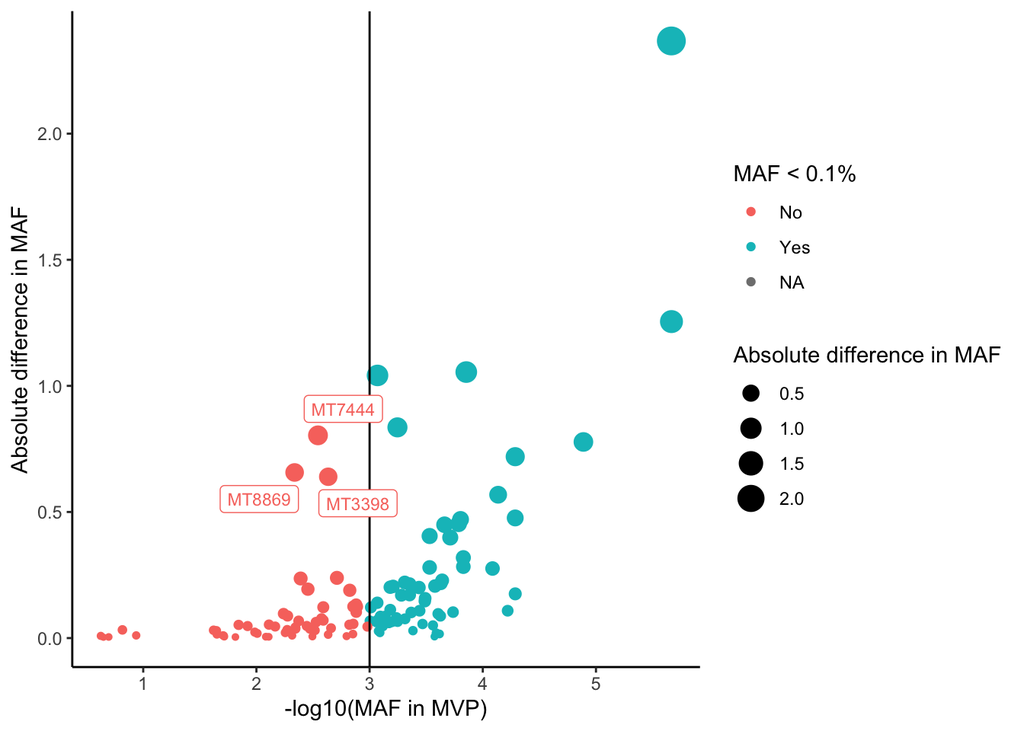

```r
library(ggrepel)
dat <- gnomAD_sum %>% select(BP, `EUR Homoplasmic AF`, EUR) %>%
  filter(!is.na(`EUR Homoplasmic AF`)) %>%
  arrange(BP) %>%
  mutate(`EUR Homoplasmic AF` = as.numeric(`EUR Homoplasmic AF`),
         EUR = as.numeric(EUR),
         BP = paste("MT", BP, sep = ""),
         `MAF < 0.1%` = ifelse(EUR > 3, "Yes", "No"),
         diff = abs(`EUR Homoplasmic AF`-EUR),
         Name = ifelse(EUR <= 3 & diff > 0.5, BP, "")) %>%
  rename(gnomAD = `EUR Homoplasmic AF`,
         MVP = EUR,
         `Absolute difference in MAF` = diff)

ggplot(dat, aes(MVP, `Absolute difference in MAF`,
                       color = `MAF < 0.1%`, size = `Absolute difference in MAF`)) +
  geom_point() +
  xlab("-log10(MAF in MVP)") +
  ylab("Absolute difference in MAF") +
  geom_vline(xintercept = 3) +
  geom_label_repel(aes(label = Name),
                  box.padding   = 0.35,
                  point.padding = 0.5,
                  segment.color = 'grey50',
                  show.legend = FALSE,
                  size = 3) +
  theme(axis.text = element_text(size = 18)) +
  theme_classic()
```

```r
ggsave("compare_MAF_gnomAD_EUR.pdf", width = 20, height = 10, units = "cm")
```

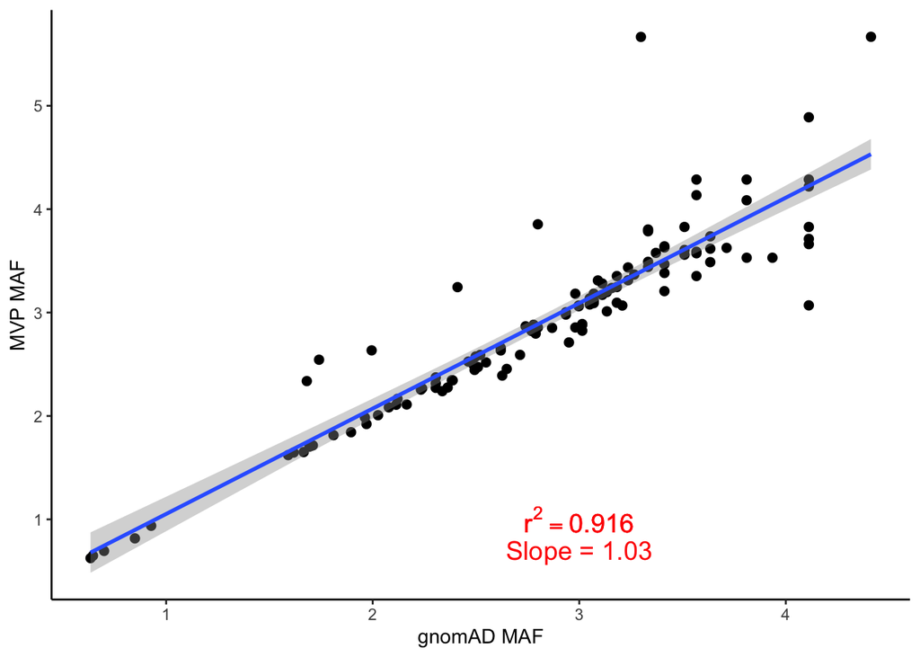

```r
ggp <- ggplot(gnomAD_sum, aes(`EUR Homoplasmic AF`, EUR)) +
  geom_point(size = 2)


rr = signif(cor(gnomAD_sum$`EUR Homoplasmic AF`, gnomAD_sum$EUR,
                                use = "pairwise.complete.obs"), 3)
tm.lm = summary(lm(EUR~ -1 + `EUR Homoplasmic AF`, data = gnomAD_sum))
slope = signif(tm.lm$coefficients[1,1], 3)

ggp +
  stat_smooth(method = "lm",
              formula = y ~ x,
              geom = "smooth") +
  xlab("gnomAD MAF") +
  ylab("MVP MAF") +
  annotate(geom = "text", x = 3, y = 1,
              label = bquote(r^2 == .(rr)),
              color="red",
           size = 5) +
  annotate(geom = "text", x = 3, y = 0.7,
           label = paste("Slope = ", slope, sep = ""),
           color= "red",
           size = 5) +
  theme_classic()
```

```r
ggsave("cor_MAF_gnomAD_EUR.pdf", width = 20, height = 10, units = "cm")
```

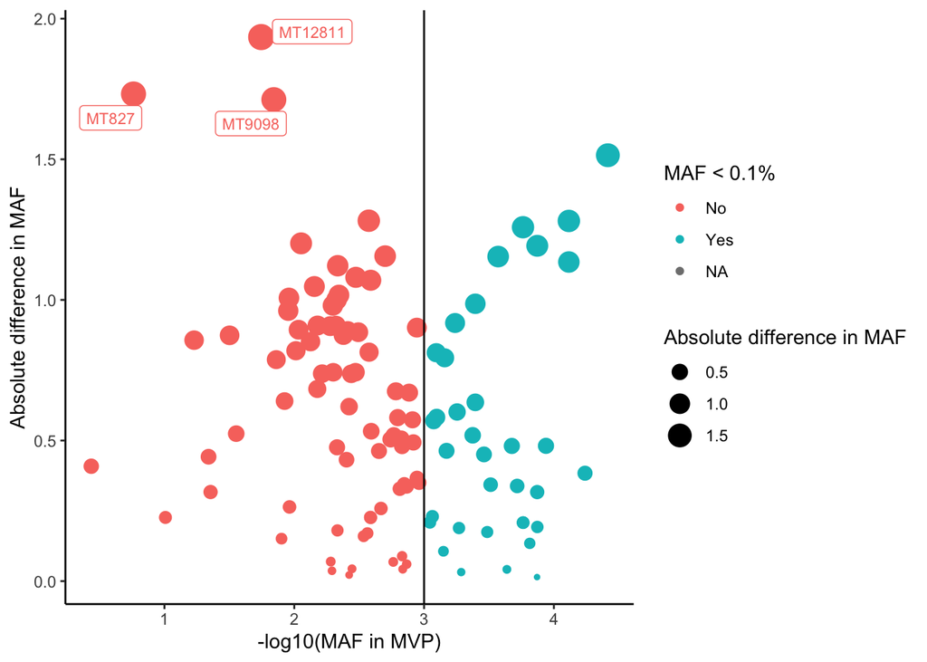

```r
library(ggrepel)
dat <- gnomAD_sum %>% select(BP, `AFR Homoplasmic AF`, AFR) %>%
  filter(!is.na(`AFR Homoplasmic AF`)) %>%
  arrange(BP) %>%
  mutate(`AFR Homoplasmic AF` = as.numeric(`AFR Homoplasmic AF`),
         AFR = as.numeric(AFR),
         BP = paste("MT", BP, sep = ""),
         `MAF < 0.1%` = ifelse(AFR > 3, "Yes", "No"),
         diff = abs(`AFR Homoplasmic AF` - AFR),
         Name = ifelse(AFR <= 3 & diff > 1.5, BP, "")) %>%
  rename(gnomAD = `AFR Homoplasmic AF`,
         MVP = AFR,
         `Absolute difference in MAF` = diff)

ggplot(dat, aes(MVP, `Absolute difference in MAF`,
                       color = `MAF < 0.1%`, size = `Absolute difference in MAF`)) +
  geom_point() +
  xlab("-log10(MAF in MVP)") +
  ylab("Absolute difference in MAF") +
  geom_vline(xintercept = 3) +
  geom_label_repel(aes(label = Name),
                  box.padding   = 0.35,
                  point.padding = 0.5,
                  segment.color = 'grey50',
                  show.legend = FALSE,
                  size = 3) +
  theme(axis.text=element_text(size = 18)) +
  theme_classic()
```

```r
ggsave("compare_MAF_gnomAD_AFR.pdf", width = 20, height = 10, units = "cm")
```

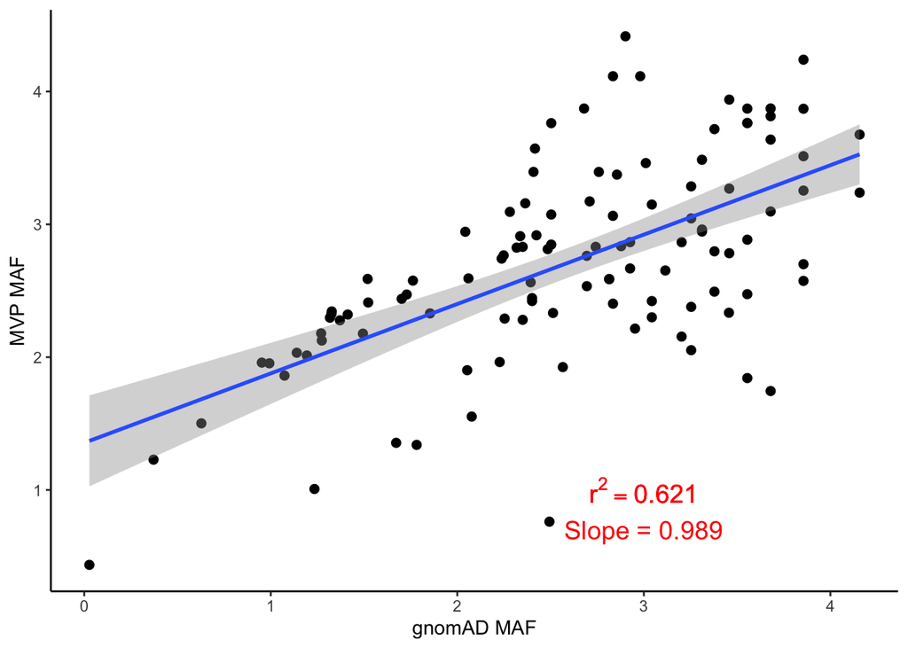

```r
ggp <- ggplot(gnomAD_sum, aes(`AFR Homoplasmic AF`, AFR)) +
  geom_point(size = 2)


rr = signif(cor(gnomAD_sum$`AFR Homoplasmic AF`, gnomAD_sum$AFR,
                                use = "pairwise.complete.obs"), 3)
tm.lm = summary(lm(AFR~ -1 + `AFR Homoplasmic AF`, data = gnomAD_sum))
slope = signif(tm.lm$coefficients[1,1], 3)


ggp +
  stat_smooth(method = "lm",
              formula = y ~ x,
              geom = "smooth") +
  xlab("gnomAD MAF") +
  ylab("MVP MAF") +
  annotate(geom = "text", x = 3, y = 1,
              label = bquote(r^2 == .(rr)),
              color="red",
           size = 5) +
  annotate(geom = "text", x = 3, y = 0.7,
           label = paste("Slope = ", slope, sep = ""),
           color= "red",
           size = 5) +
  theme_classic()
```

```r
ggsave("cor_MAF_gnomAD_AFR.pdf", width = 20, height = 10, units = "cm")
```

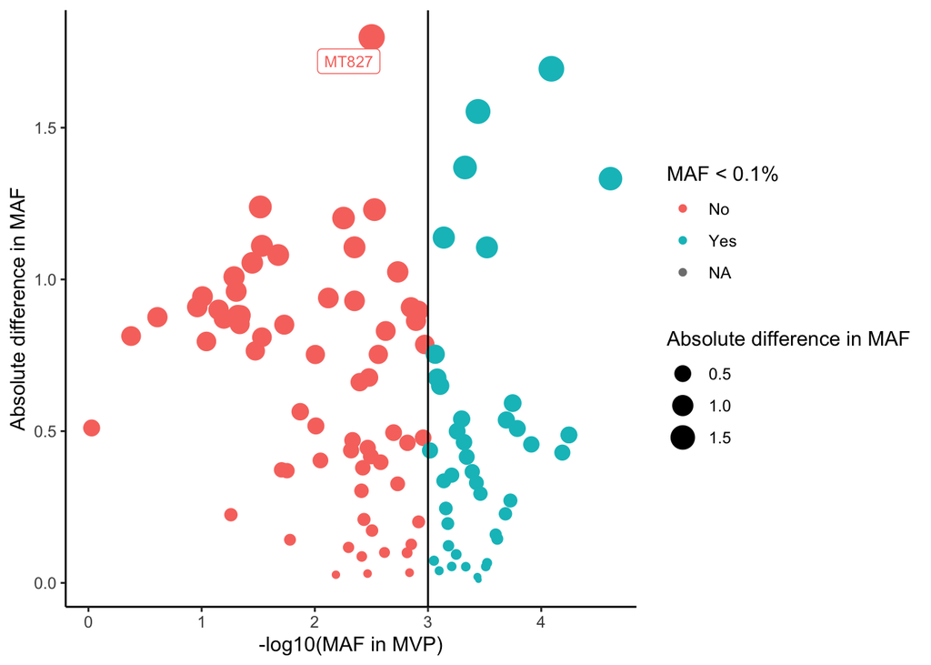

```r
library(ggrepel)
dat <- gnomAD_sum %>% select(BP, `AMF Homoplasmic AF`, AMF) %>%
  filter(!is.na(`AMF Homoplasmic AF`)) %>%
  arrange(BP) %>%
  mutate(`AMF Homoplasmic AF` = as.numeric(`AMF Homoplasmic AF`),
         AMF = as.numeric(AMF),
         BP = paste("MT", BP, sep = ""),
         `MAF < 0.1%` = ifelse(AMF > 3, "Yes", "No"),
         diff = abs(`AMF Homoplasmic AF` - AMF),
         Name = ifelse(AMF <= 3 & diff > 1.5, BP, "")) %>%
  rename(gnomAD = `AMF Homoplasmic AF`,
         MVP = AMF,
         `Absolute difference in MAF` = diff)

ggplot(dat, aes(MVP, `Absolute difference in MAF`,
                       color = `MAF < 0.1%`, size = `Absolute difference in MAF`)) +
  geom_point() +
  xlab("-log10(MAF in MVP)") +
  ylab("Absolute difference in MAF") +
  geom_vline(xintercept = 3) +
  geom_label_repel(aes(label = Name),
                  box.padding   = 0.35,
                  point.padding = 0.5,
                  segment.color = 'grey50',
                  show.legend = FALSE,
                  size = 3) +
  theme(axis.text=element_text(size = 18)) +
  theme_classic()
```

```r
ggsave("compare_MAF_gnomAD_AMR.pdf", width = 20, height = 10, units = "cm")
```

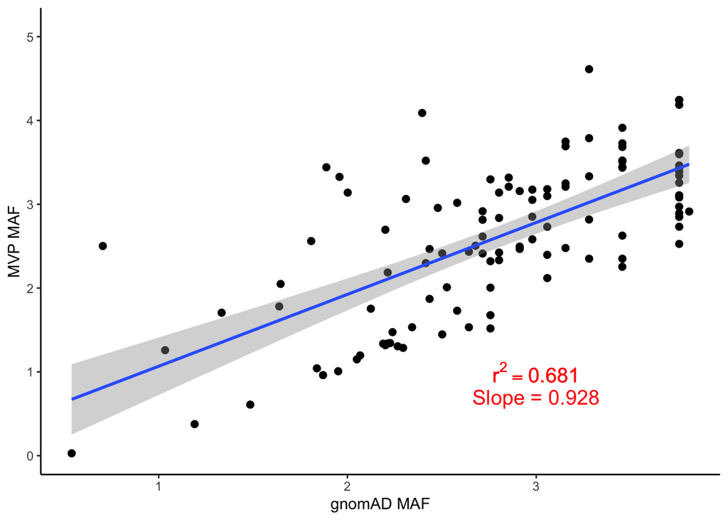

```r
ggp <- ggplot(gnomAD_sum, aes(`AMF Homoplasmic AF`, AMF)) +
  geom_point(size = 2)


rr = signif(cor(gnomAD_sum$`AMF Homoplasmic AF`, gnomAD_sum$AMF,
                                use = "pairwise.complete.obs"), 3)

tm.lm = summary(lm(AMF~ -1 + `AMF Homoplasmic AF`, data = gnomAD_sum))
slope = signif(tm.lm$coefficients[1,1], 3)

ggp +
  stat_smooth(method = "lm",
              formula = y ~ x,
              geom = "smooth") +
  xlab("gnomAD MAF") +
  ylab("MVP MAF") +
  annotate(geom = "text", x = 3, y = 1,
              label = bquote(r^2 == .(rr)),
              color="red",
           size = 5) +
  annotate(geom = "text", x = 3, y = 0.7,
           label = paste("Slope = ", slope, sep = ""),
           color= "red",
           size = 5) +
  theme_classic()
```

```r
ggsave("cor_MAF_gnomAD_AMR.pdf", width = 20, height = 10, units = "cm")
```

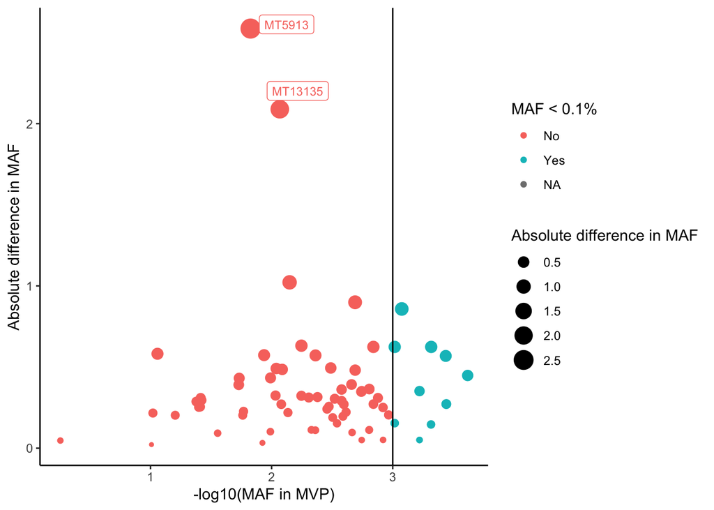

```r
library(ggrepel)
dat <- gnomAD_sum %>% select(BP, `EAS Homoplasmic AF`, EAS) %>%
  filter(!is.na(`EAS Homoplasmic AF`)) %>%
  arrange(BP) %>%
  mutate(`EAS Homoplasmic AF` = as.numeric(`EAS Homoplasmic AF`),
         EAS = as.numeric(EAS),
         BP = paste("MT", BP, sep = ""),
         `MAF < 0.1%` = ifelse(EAS > 3, "Yes", "No"),
         diff = abs(`EAS Homoplasmic AF` - EAS),
         Name = ifelse(EAS <= 3 & diff > 1.5, BP, "")) %>%
  rename(gnomAD = `EAS Homoplasmic AF`,
         MVP = EAS,
         `Absolute difference in MAF` = diff)

ggplot(dat, aes(MVP, `Absolute difference in MAF`,
                       color = `MAF < 0.1%`, size = `Absolute difference in MAF`)) +
  geom_point() +
  xlab("-log10(MAF in MVP)") +
  ylab("Absolute difference in MAF") +
  geom_vline(xintercept = 3) +
  geom_label_repel(aes(label = Name),
                  box.padding   = 0.35,
                  point.padding = 0.5,
                  segment.color = 'grey50',
                  show.legend = FALSE,
                  size = 3) +
  theme(axis.text=element_text(size = 18)) +
  theme_classic()
```

```r
ggsave("compare_MAF_gnomAD_EAS.pdf", width = 20, height = 10, units = "cm")
```

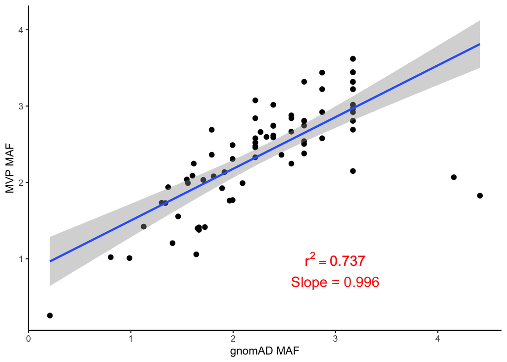

```r
ggp <- ggplot(gnomAD_sum, aes(`EAS Homoplasmic AF`, EAS)) +
  geom_point(size = 2)


rr = signif(cor(gnomAD_sum$`EAS Homoplasmic AF`, gnomAD_sum$EAS,
                                use = "pairwise.complete.obs"), 3)

tm.lm = summary(lm(EAS~ -1 + `EAS Homoplasmic AF`, data = gnomAD_sum))
slope = signif(tm.lm$coefficients[1,1], 3)

ggp +
  stat_smooth(method = "lm",
              formula = y ~ x,
              geom = "smooth") +
  xlab("gnomAD MAF") +
  ylab("MVP MAF") +
  annotate(geom = "text", x = 3, y = 1,
            label = bquote(r^2 == .(rr)),
            color = "red",
           size = 5) +
  annotate(geom = "text", x = 3, y = 0.7,
           label = paste("Slope = ", slope, sep = ""),
           color= "red",
           size = 5) +
  theme_classic()
```

```r
ggsave("cor_MAF_gnomAD_EAS.pdf", width = 20, height = 10, units = "cm")
```

## Combined gene-based solar plot (gray genes version)

- Data setup

```r
### MT Gene-based data #####

dat <- d_gene %>% filter(SEX == "allsex" | POP == "all") # %>% dplyr::select(-bonf)
dat_sig <- gene_sig_fdr #%>% dplyr::select(-bonf)

# Creates and stores negative log p as a new variable
dat$neglogp <- -log10(dat$P.value)

# Adds line to y axis
#dat$extraline <- -log10(5E-5)
#extraline <- -log10(0.05/nrow(dat))

nphecodes <- length(unique(dat$phecode))

dat_plot <- dat %>%
  left_join(dat_sig) %>%
  mutate(sig = ifelse(!is.na(P.value.adj.fdr), 1, 0)) %>%
  dplyr::rename(Gene = SetID) %>%
  mutate(Gene = gsub("MT-", "", Gene)) %>%
  left_join(refflat_length) %>%
  arrange(Gene,as.numeric(phecode)) %>%
  #mutate(runlength = cumsum(unique(gene_length)) - gene_length[1]) %>%
  group_by(Gene) %>%
  mutate(length_nrow_ratio = dplyr::n()/gene_length,
       phe_pos = row_number()/length_nrow_ratio,
       POS = phe_pos + start)
```

```
## trait, MAF_cutoff, SEX, POP, NPC, prop_cases, n_cases, phecode, description,
## group)`
```

```r
  #filter(phecode %in% dat_sig$phecode) %>%
  #filter(P.value != 0 & !is.na(P.value))
#table(dat_plot$phecode)
```

- Colours

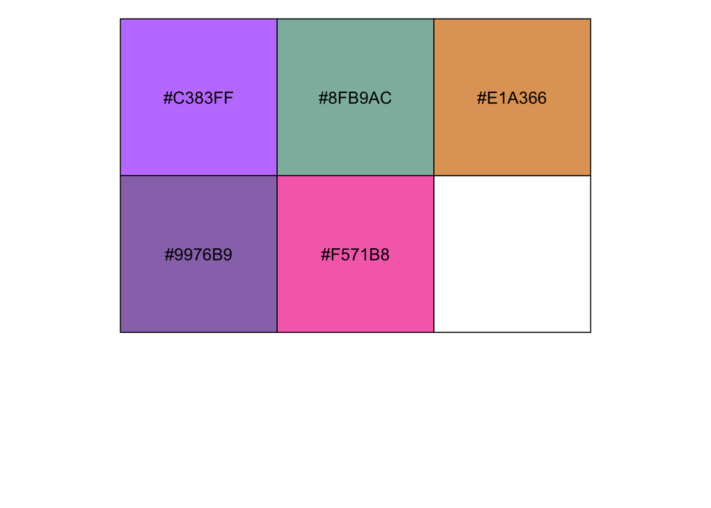

```r
###colours_ct <- colours[!grepl("^T", names(colours))]
colours_gw <- colours
colours_gw[1:length(colours_gw)] <- rep(c("gray50", "gray60", "gray70"), 100)[1:length(colours)]
##show_col(colours_ct)
##colours_pop <- c("gray20", "#E16666", "#6666E1", "#98B998", "#FFBA66")

# Define colours for population key
colours_pop <- c("gray20", "#E16666", "#6666E1", "#98B998", "#B9ADA3") #lighten peachpuff4
names(colours_pop) <- sort(sex_pop_key2[grepl("All", sex_pop_key)])

#colours_group <- lapply(c("purple1", "purple4","deeppink2", "deeppink4"), lighten_col) %>% unlist()
##colours_group <- lapply(c("purple1", "purple4","deeppink2", "deeppink4", "aquamarine4"), lighten_col) %>% unlist()

#Define colours for phecode group key
colours_group <- lapply(c("purple1", "aquamarine4", "darkorange3", "purple4", "deeppink2"), lighten_col) %>% unlist()
names(colours_group) <- c("circulatory system", "endocrine/metabolic", "digestive", "congenital anomalies", "biomarkers")
show_col(colours_group)
```

```r
#colorscale_plot <- c(colours_gw, colours_pop)

# Define colourscale including both population and phecode group (they use the same aesthetic mapping)
colorscale_plot <- c(colours_group, colours_pop)
```

- Plot

```r
c_radius <- 6.5
dat_plot2 <- dat_plot %>%
  mutate(Population = sex_pop_key2[paste0(POP,SEX)],
         `Genetically Inferred Ancestry` = race_key[RACE]) %>%
  mutate(
    #Gene_orig = Gene, Gene = ifelse(grepl("^T", Gene), "tRNA", Gene),
       gene_lbl = ifelse(sig, Gene, NA),
       description = ifelse(is.na(description), biomarker_key[trait], description),
       description_shortened = gsub("[;,]* and ", "/", description),
       #phecode_title1 = paste0(phecode, "\n(", description_shortened, ")"), #two lines label
       phecode_title2 = paste0(phecode, "-", description_shortened),   #one line label
       #lbl1 = ifelse(sig, phecode_title1, ""),
       lbl2 = ifelse(sig, phecode_title2, ""),
       lbl2 = ifelse(is.na(group) & sig, biomarker_key[trait], lbl2),
       lbl3 = ifelse(sig & ((Gene %in% c("ATP6", "ATP8", "CO3", "ND6", "ND1") & phecode != "426") |
                              (Gene == "RNR1" & trait == "tg")),
                     paste0(lbl2, "\n(", gene_lbl, ")"), lbl2),  #Add the gene label for significant points that are close to the gene border
       lbl_extra = ifelse(sig, paste0("(", gene_lbl, ", ", Population, ")"), NA),
       lbl4 = ifelse(sig, paste0(lbl2, "\n", lbl_extra), NA), #Add the gene AND population label for all points.
       #psize = ifelse(sig, 3, 1),
       points_gray = ifelse(sig, NA, POS), #NONsignificant points
       points_colored = ifelse(sig, POS, NA), #significant points
       group = ifelse(is.na(group), "biomarkers", group)) #%>%
  # ungroup() %>%
  # # mutate(degree = 360*(POS/max(POS)),
  # #        ang = degree - 270 - ifelse(degree <= 180, 180, 0)) %>%
  # group_by(Gene) %>%
  # #mutate(gene_ymax = max(neglogp)) %>%
  # ungroup()
  # #arrange(desc(neglogp)) %>%
  # #hist(dat_plot2$degree)

fplot <- ggplot(dat_plot2) +
  ylim(0, max(dat_plot$neglogp) + c_radius + 1) +
  coord_polar(direction = -1, clip = "off") +
  #guides(fill=guide_legend(ncol=2)) +
  guides(fill = "none") +
  guides(size = "none") +
  #guides(color=guide_legend(ncol=2)) +
  #guides(color="none", size = "none") +
  #geom_line(aes(x, 5,color = "red"), data = lines, size = 1.5) +
  #facet_grid(.~phecode_title) +
  theme_minimal() +
  #geom_hline(aes(yintercept=extraline + c_radius), color = "red") +
  geom_hline(aes(yintercept=c_radius + 1), color = "gray", size = 0.1) +
  geom_hline(aes(yintercept=c_radius + 2), color = "gray", size = 0.1) +
  geom_hline(aes(yintercept=c_radius + 3), color = "gray", size = 0.1) +
  geom_hline(aes(yintercept=c_radius + 4), color = "gray", size = 0.1) +
  geom_hline(aes(yintercept=c_radius + 5), color = "gray", size = 0.1) +
  geom_hline(aes(yintercept=c_radius + 6), color = "gray", size = 0.1) +
  geom_hline(aes(yintercept=c_radius + 7), color = "gray", size = 0.1) +
  geom_hline(aes(yintercept=c_radius + 8), color = "gray", size = 0.1) +
  geom_hline(aes(yintercept=c_radius + 9), color = "gray", size = 0.1) +
  geom_hline(aes(yintercept=c_radius + 10), color = "gray", size = 0.1) +
  geom_rect(data=refflat, # Gene bands
            aes(xmin=start, xmax=end, ymin=c_radius-1.2, ymax=c_radius-0.2, fill=gene),
            inherit.aes = F, show.legend = F) +
  geom_textpath(data=refflat_length, # Gene labels on the band (for larger genes)
                aes(x=start + gene_length/2, y=c_radius - 0.7,
                    label = ifelse(small_gene, NA, Gene),
                    #label = Gene,
                    angle=ifelse(small_gene, 90, 0),
                    size = ifelse(small_gene, 1.5, 5)),
                inherit.aes=F, show.legend=F) +
  geom_point(aes(x=points_gray, y=neglogp + c_radius, shape = `Genetically Inferred Ancestry`, #plot non-significant points (by phecode group)
                 color=group), size=1) + #, color = "gray65") +
  geom_point(aes(x=points_colored, y=neglogp + c_radius, color = group, #Population, #plot significant points in different color scale (population)
                 shape = `Genetically Inferred Ancestry`, size=psize), size=3.5 ) +
  geom_text_repel(aes(x=POS, y=neglogp + c_radius, label = lbl4), #lbl3), #label significant points
                show.legend=F, max.overlaps=Inf, max.time = 20, color = "gray1", size=3,
                #min.segment.length = .1, force = 3, nudge_y=0.2,
                box.padding = unit(0.75, "lines")) +
  # geom_text_repel(data=refflat_length, #label small genes - ggrepel won't work for this due to polar coordinates
  #               aes(x=start + gene_length/2, y=c_radius - 0.2,
  #                   angle = 90 - ifelse(pos.rt >= 180, pos.rt - 180, pos.rt),
  #                   label = ifelse(small_gene, Gene, "")),
  #                   #angle=ifelse(small_gene, 90, 0),
  #               #size = ifelse(small_gene, 1.5, 5)),
  #               inherit.aes=F,
  #               max.overlaps = Inf,
  #               size=3, min.segment.length = 0,
  #               force_pull = 3,
  #               #ylim = c(c_radius+ 7.5, c_radius + 8.5), #NOT RESPECTED IN POLAR COORDINATES
  #               direction = "x", #nudge_y=0.5,
  #               show.legend=F) +
  geom_text(data=refflat_length_small_plothelp, #label small genes that don't fit well in the bands - define above
                aes(x=plot_pos, y=c_radius + .25,
                    angle = 90 - ifelse(pos.rt >= 180, pos.rt - 180, pos.rt),
                    label = Gene),
                    #angle=ifelse(small_gene, 90, 0),
                #size = ifelse(small_gene, 1.5, 5)),
                inherit.aes=F, size=3, show.legend=F) +
  scale_colour_manual(##values = c("black", "red", "blue", "green", "orange"),
                      ##values = c("gray20", "#E16666", "#6666E1", "#98B998", "#FFBA66"),
                      ######values = colorscale_plot, #includes both phecode group and population
                      values = colours_group,
                      #breaks = names(colorscale_plot)[grepl("All", names(colorscale_plot))],
                      ###"Population Phecode Type",
                      "Phecode Type",
                      #breaks = names(colours_ct),
                      #labels = colours_ct
                      ) +
  scale_fill_manual(values = colours_gw, #fill in the gene bands with gray colors
                      "",
                      breaks = names(colours_gw),
                      #labels = names(colours_gw)
                    ) +
  #xlab("Mitochondrial Base-Pair Location") +
  xlab("") +
  ylab("-log(p-value)") +
  #ggtitle("Negative Log P-value of Mitochondrial Hits") +
  ggtitle("Gene-based analysis") +
   theme(axis.text.x = element_blank(),
         axis.text.y = element_blank(),
         axis.ticks.y = element_blank(),
  #       legend.position = "none",
         panel.grid = element_blank()) +
  #theme(legend.key.size = unit(.7, 'cm')) +
  #scale_shape_manual(values = letters[univ$Id],
   #          guide = guide_legend(override.aes = list(alpha = 1,
    #                                                  size = 3))) +
  scale_shape_manual(values=c(15,16,17,9)) + #
  scale_size(range=c(2, 3.5)) # finicky
#fplot

# ggsave("../images/genebased_images/combined_fdr_solarplot_genebased_gray_group_v2.png", fplot,
#      w=12, h=10, dpi=400, bg = "white")
# ggsave("../images/genebased_images/combined_fdr_solarplot_genebased_labelPop.png", fplot,
#     w=12, h=10, dpi=400, bg = "white")
```

## Summplementary Table 8: Summary of Number of markers per set

```r
gene_summary <- fread("../genebased/MT/SKATO.GIA.15PC.all_traits.result.txt") %>%
  filter(COHORT == "vPAD") %>%
  filter(grepl("GIA", RACE)) %>%
  filter(SEX == "allsex" & POP == "all") %>%
  filter(grepl("phe", trait)) %>%
  distinct(RACE, SetID, N.Marker.Test) %>%
  dplyr::rename(GIA = RACE) %>%
  mutate(GIA = gsub("_GIA", "", GIA),
         SetID = gsub("MT-", "", SetID)) %>%
  pivot_wider(id_cols = GIA, names_from = SetID, values_from = "N.Marker.Test") %>%
  data.frame()

##write.xlsx2(gene_summary, "../summary/MVP_summaries/N.Markers.summary.xlsx", row.names = F)
```